# NBA Player of the Week

# Library Used

```r
library(dplyr)
library(lubridate)
library(ggplot2)
library(ggrepel)
library(ggalt)
```

# Dataset

The data was scraped from Basketball real gm site, The idea of making this data set was to explore regular season domination. Whether the seniority / last contract year etc. has an affect on the long run.

Pulling the CSV file from kaggle https://www.kaggle.com/jacobbaruch/nba-player-of-the-week,

```r
data <- read.csv("NBA_player_of_the_week 2.csv",stringsAsFactors = F)
```

# Summary on Fields

1. Age

We observe the following the dataset has age ranging from 19-40, this can be considered to be one of the important field as the user want to see if the seniority is having impact on the rewards at different conference.

```r
summary(data$Age)
```

```
   Min. 1st Qu.  Median    Mean 3rd Qu.    Max.
  19.00   24.00   26.00   26.77   29.00   40.00
```

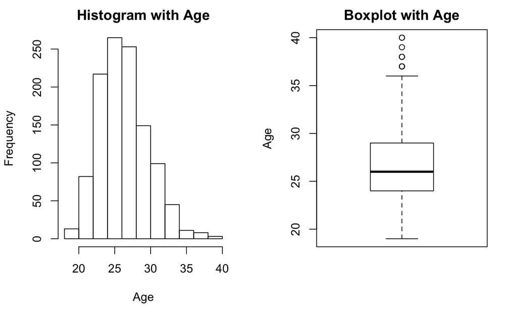

```r
par(mfrow=c(1,2))
hist(data$Age,xlab="Age",main="Histogram with Age")
boxplot(data$Age,ylab="Age",main="Boxplot with Age")
```

Observe not many people at higher age can be found they show it to be outlier, but they are valid.

2. Conference

We observe lotsa of missing values for the conference nearly 384 samples are not having values. These values can be filled based on the Teams and Since Washington Bullets were renamed Washington Wizards in 1997, some of the values were missing.

```r
table(data$Conference)
```

```
     East West
 384  381  380
```

```r
east_teams <- (data %>% filter(Conference=='East') %>% distinct(Team))$Team
west_teams <- (data %>% filter(Conference=='West') %>% distinct(Team))$Team
(data %>% filter(Team=='Washington Wizards' | Team=='Washington Bullets')%>%distinct(Conference))$Conference
```

```
[1] ""     "East"
```

```r
imputeConference <- function(conf,team){
  if(conf==''){
      if(team %in% east_teams || team =='Washington Bullets'){
        return('East')
      }
      else if ( team %in% west_teams){
        return('West')
      }else{
        return('')
      }
  }else{
    return(conf)
  }
}
conf <- mapply(imputeConference, data$Conference,data$Team)
table(conf)
```

```
conf
East West
 564  581
```

```r
data$Conference <- conf
```

3.Date It is the awarded date for each of the player, they are in free text which needs to be converted to datatime using the lubridate function

```r
summary(data$Date)
```

```
   Length     Class      Mode
     1145 character character
```

```r
dt <-mdy(data$Date)
summary(dt)
```

```
        Min.      1st Qu.       Median         Mean      3rd Qu.         Max.
"1984-11-04" "1997-01-05" "2005-11-21" "2004-04-11" "2012-02-20" "2018-04-09"
```

```r
data$Date <-dt
```

4.Draft.Year It defines the player drafted year. There is no data preparation required on this column

```r
summary(data$Draft.Year)
```

```
   Min. 1st Qu.  Median    Mean 3rd Qu.    Max.
   1969    1990    1998    1997    2004    2016
```

5. Height

Height is defined in foot-inches, converting into cm

```r
str(data$Height)
```

```
 chr [1:1145] "6-5" "6-6" "6-6" "7-2" "6-9" "6-4" "6-3" "6-6" "6-9" "6-7" "6-11" "6-6" "6-2" "6-1" "6-5" ...
```

```r
to_uniform_height <- function (input){
  if(grepl('cm',input) == TRUE){
    return (as.numeric(gsub('cm','',input)))
  }else{
    val <- strsplit(input,split = '-')
    return((as.numeric(val[[1]][1])*12+as.numeric(val[[1]][2]))*2.54)
  }
}
ht <- mapply(to_uniform_height,data$Height)
summary(ht)
```

```
   Min. 1st Qu.  Median    Mean 3rd Qu.    Max.
  175.0   193.0   201.0   201.0   208.3   228.6
```

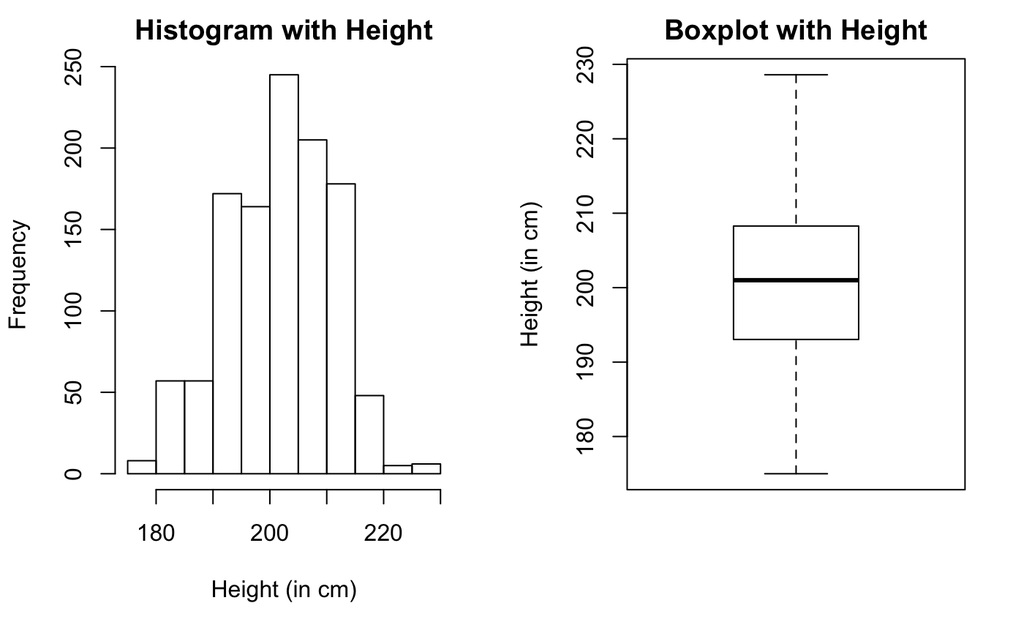

```r
par(mfrow=c(1,2))
hist(ht,xlab="Height (in cm)",main="Histogram with Height")
boxplot(ht,ylab="Height (in cm)",main="Boxplot with Height")
```

```r
data$Height <-ht
```

6. Player

It defines the player name, analyzing if the player names are missing, No rows are missing

```r
data %>% filter(Player=='' | is.na(Player)) %>% nrow()
```

```
[1] 0
```

7.Position It defines the posittion of the player, there are basically 5 common’[Basketball Positions](https://en.wikipedia.org/wiki/Basketball_positions), Here we are observing more positions, hence requires cleanup. C -> Center F -> Forward FC/F-C -> Forward Center G -> Guard GF/G-F -> Guard Forward PF -> Power Forward PG -> Power Guard SF -> Shooting Forward SG -> Shooting Guard

```r
position_map<-list('C'='Center','F'='Forward','FC'='Forward Center','F-C'='Forward Center','G'='Guard', 'GF'='Guard Forward','G-F'='Guard Forward','PF'='Power Forward','PG'='Power Guard', 'SF'='Shooting Forward', 'SG'='Shooting Guard')
rename_position<-function(pos){
  return(position_map[pos][[1]])
}
pos<-as.factor(mapply(rename_position,data$Position))
summary(pos)
```

```
          Center          Forward   Forward Center            Guard    Guard Forward    Power Forward
             158              125               92              178               50              139
     Power Guard Shooting Forward   Shooting Guard
             120              119              164
```

```r
data$Position <- pos
```

8.Season and Season.short

Validating if the searson and season.short are correct for all scenarios.

```r
seasonEnd <-mapply(function(t) t[2],strsplit(data$Season,split='-'))
data$Season <- as.factor(data$Season)
all(seasonEnd==data$Season.short)
```

```
[1] TRUE
```

```r
summary(data$Season.short)
```

```
   Min. 1st Qu.  Median    Mean 3rd Qu.    Max.
   1985    1997    2006    2004    2012    2018
```

9. Weight

Weight of the player are define in pounds, but for some of the observation values are defined in KG

```r
to_uniform_weight <- function (input){
  if(grepl('kg',input) == TRUE){
    return (as.numeric(gsub('kg','',input)))
  }else{
    return(as.numeric(input)*0.453592)
  }
}
wt <- mapply(to_uniform_weight,data$Weight)
summary(wt)
```

```
   Min. 1st Qu.  Median    Mean 3rd Qu.    Max.
  68.04   92.99  102.06  102.51  113.40  147.42
```

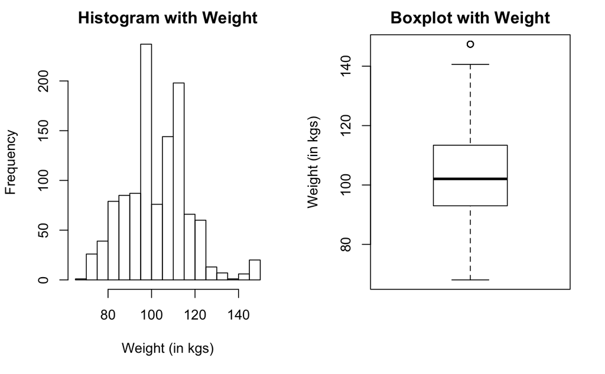

```r
par(mfrow=c(1,2))
hist(wt,xlab="Weight (in kgs)",main="Histogram with Weight")
boxplot(wt,ylab="Weight (in kgs)",main="Boxplot with Weight")
```

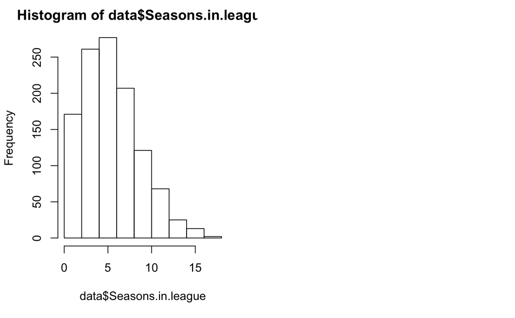

```r
data$Weight<-wt
hist(data$Seasons.in.league);
```

10. Real Value Number of awards in a season, there are two possible values 0.5 and 1. As per data dictionaty player either gets 0.5 if he winsawards on both East and West Conference.

```r
summary(as.factor(data$Real_value))
```

```
0.5   1
761 384
```

# Correlation of # Awards with Height and Weight

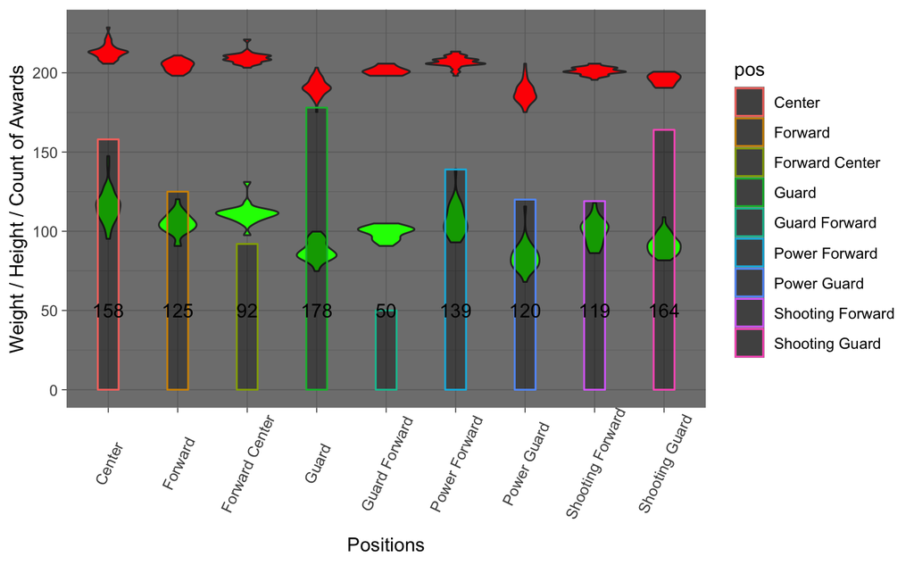

```r
report <- data%>% select(Player,Height,Weight,Position) %>% group_by(Player) %>% summarise(
   ht = mean(Height),
    wt = mean(Weight),
    pos = first(Position),
    num_awards = n()) %>% arrange(-num_awards);
awards_per_pos <-report %>% group_by(pos) %>% summarise(num_awards=sum(num_awards))
theme_set(theme_dark())
ggplot(report,aes(x=pos)) + geom_violin(aes(y=ht),fill="red") +
    geom_violin(aes(y=wt),fill="green") +
    geom_bar(aes(y=num_awards,col=pos),fill="black",stat="summary",fun.y="sum",width=0.3,alpha=0.4) +
    geom_text(data=awards_per_pos,aes(y=50,label=num_awards)) +
    theme(axis.text.x = element_text(angle=65, vjust=0.6)) +labs(x = "Positions",y = "Weight / Height / Count of Awards");
```

```r
NA
```

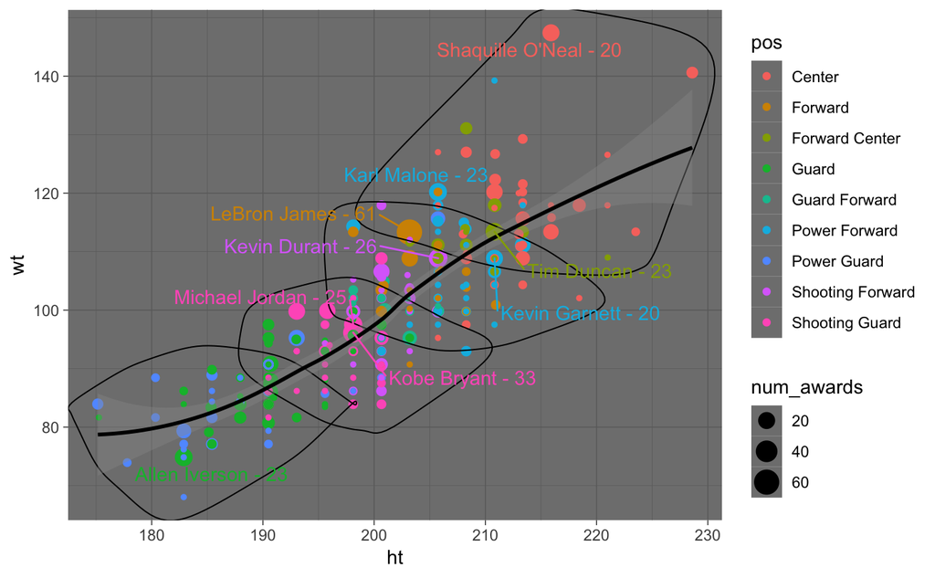

```r
theme_set(theme_dark())
set.seed(71093)
df <-data.frame(list(ht=report$ht,wt=report$wt,awards=report$num_awards))
df <-data.frame(list(ht=report$ht,wt=report$wt))
cl <-kmeans(df,centers =4)
ggplot(report,aes(x=ht,y=wt)) +
    geom_point(aes(size=num_awards,col=pos)) +
    geom_encircle(data=report[cl$cluster==1,],aes(x=ht,y=wt)) +
    geom_encircle(data=report[cl$cluster==2,],aes(x=ht,y=wt)) +
    geom_encircle(data=report[cl$cluster==3,],aes(x=ht,y=wt)) +
    geom_encircle(data=report[cl$cluster==4,],aes(x=ht,y=wt)) +
    #geom_encircle(data=report[cl$cluster==5,],aes(x=ht,y=wt)) +
    geom_smooth(col="black", method = 'loess' , formula='y ~ x') +
    geom_text_repel(aes(label=ifelse(num_awards>=20,paste(Player,'-',num_awards),''),color=pos), force=10, show.legend=F) ;
```

```r
NA
```

# Year and Year Performance of Top Players (more than 20 awards)

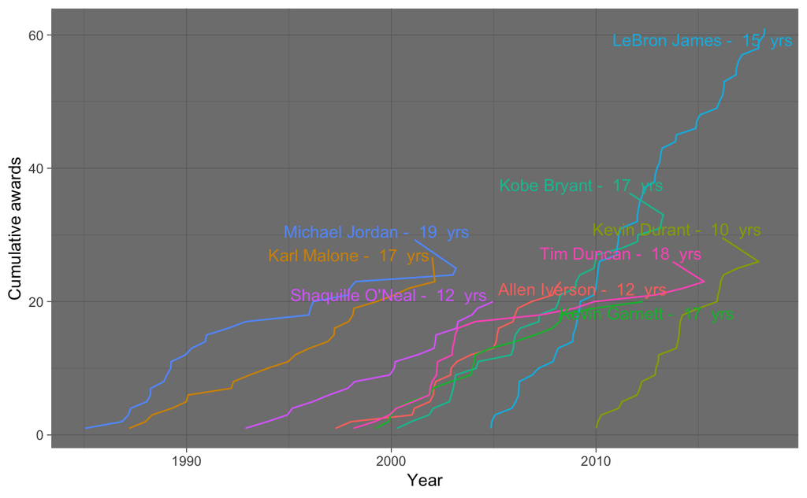

# Lebron James & Kobe Bryant the most prolific Week

Basketball season starts in October and goes till April, We observe the LeBron James ruthless at start and end of season while Kobe flourishes in mid.

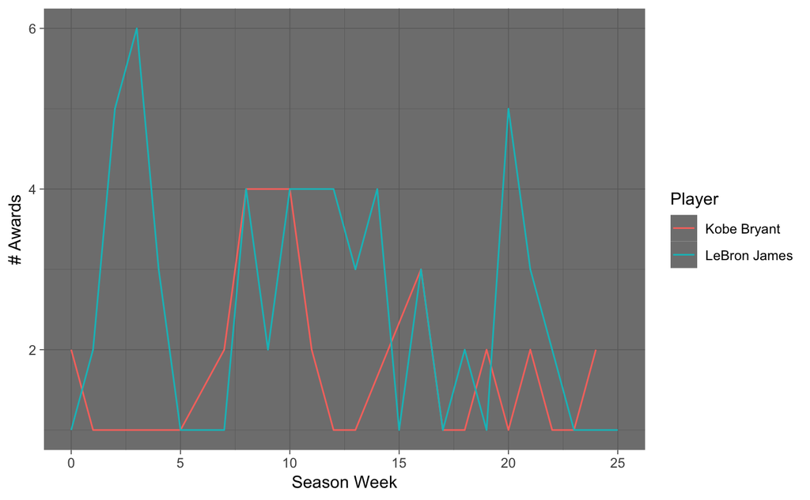